# Homework answers

Xinyi C

2020-12-20

## Overview

That is the all functions for all homework answers.

## 2020-09-22

The source R code for the answers is as follows:

Example 1

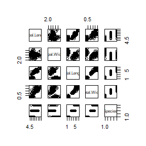

```r
plot(iris)
```

Example 2

```r
knitr::kable(head(cars))
```

| speed | dist |
| --- | --- |
| 4 | 2 |
| 4 | 10 |
| 7 | 4 |
| 7 | 22 |
| 8 | 16 |
| 9 | 10 |

Example 3

$$\ f(n)=n^6+4n^3+5|_{n = 45}$$

$$\cos(3\theta)=\cos^3\theta-\sin^3\theta$$

$$\sqrt[n+2]{a}$$

## 2020-09-29

*1.exercise* The source R code for the answers is as follows: If $X$ is a continuous random variable with cdf $F_{X}(x),$ then $U=F_{X}(X) \sim$ Uniform(0,1). $F_{X}^{-1}(U)$ has the same distribution as $X$. The Pareto(a, b) distribution has cdf
$$F(x)=1-\left(\frac{b}{x}\right)^{a}, \quad x \geq b>0, a>0$$
X has density function
$$p(x)=\frac{\ a*b^{\alpha}}{x^{\alpha+1}}$$
and x can be presented as
$$x=\ {b(1-u)}^{-\frac{1}{\alpha}}$$

```r
n <- 1000
u <- runif(n)
x <- 2*((1-u)^(-1/2))
hist(x, prob = TRUE, main = expression(Pareto(2, 2)))
y <- seq(0, 100, .01)
lines(y,8/(y^3) )
```

*2.exrecise* The source R code for the answers is as follows:

As the question shows that the x is a symmetric density function $\ f_{e}(x)=\frac{3}{4}\left(1-x^{2}\right), \quad|x| \leq 1$ We can know by calculation that the probability density function of $U_{1}, U_{2}, U_{3}$ is $\ p(U_{i})=\frac{1}{2}I_{ \left\{\ -1\le U_i\le 1 \right\} }$
$$\ F_{x}=p(U<x)=p(|U_{3}|<|U_{1}|\ or|U_{3}|<|U_{2}|,U<U_{3})+p(|U_{3}|\geq|U_{1}|,|U_{3}|\geq|U_{2}|,U<U_{2})$$
$$\begin{aligned} p(|U_{3}|\ge|U_{1}|,|U_{3}|\ge|U_{2}|,U<U_{2}) &=\frac{1}{8} \int_{-1}^{x}d u_{2} \int_{\left|U_{3}\right| \geq\left|U_{2}\right|} d u_{3} \int_{\left|U_{3}\right|<\left|U_{1}\right|} d u_{1} \\ &=\frac{1}{8} \int_{-1}^{x} d u_{2} \int_{\left|U_{3}\right| \geq\left|U_{2}\right|}\left(1-u_{3}\right) d u_{3} \end{aligned}$$
$$\begin{aligned} p(|U_{3}|<|U_{1}|\ or|U_{3}|<|U_{2}|,U<U_{3}) &=-\int_{-1}^{1} d u_{3} \int_{\left|U_{3}\right| \geq\left|U_{2}\right|} d u_{2} \int_{\left|U_{3}\right| \geq\left|U_{1}\right|} d u_{1}+\frac{1+x}{2}
\end{aligned}$$
$$\ F_{e}(x)=p_{e}(U<x)=\frac{3x}{4}-\frac{1}{4}x^3$$
$$\ f_{e}(x)=\frac{3}{4}\left(1-x^{2}\right), \quad|x| \leq 1$$
Conclusion satisfied.

*3.exercise* The source R code for the answers is as follows:

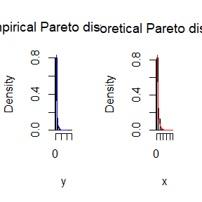

```r
n <- 1000;
u <- runif(n);
y <- 2*((1-u)^(-1/4))-2;
m <- 1000;
r <- 4;
beta <- 2;
lambda <- rgamma(m, r, beta)
x <- rexp(m, lambda)
par(mfrow=c(1,2))
hist(y, prob = TRUE, main = expression("Empirical Pareto distribution"))
y <- seq(0, 10, .01)
lines(y, r*(beta^r)*((beta+y)^(-r-1)),col="blue")
hist(x, prob = TRUE, main = expression("Theoretical Pareto distribution"))
x <- seq(0, 10, .01)
lines(x, r*(beta^r)*((beta+x)^(-r-1)),col="red")
```

## 2020-10-13

*1.exercise* The source R code for the answers is as follows:

$$\int_{0}^{\pi/3}\sin t d t=\pi/3*E(sin x)$$
, where
$$\ x \sim U(0,\pi/3)$$

```r
festim<-function(a){
x<-runif(a,min=0,max=pi/3)
theta.hat<-mean(sin(x))*(pi/3)##theta.hat表示monte carlo方法生成的估计值
print(c(theta.hat,1-cos(pi/3)))##theta.hat表示由monte carlo方法生成的估计值与理论值
}
festim(1e4)
```

```
## [1] 0.4908154 0.5000000
```

theta,hat represents the estimator of $\theta$. AS we can see the results,the difference between the result and the theoretical value is not big.

*2.exercise* The source R code for the answers is as follows:

$$\theta=\int_{0}^{\ 1}\ e^x d x$$

```r
mcesit<-function(x,antithetic=TRUE){
u<-runif(x/2)
if(!antithetic)v<-runif(x/2)
else
  v<-1-u
u<-c(u,v)
xdf<-mean(exp(u))

}
set.seed(123)
mc1<-mcesit(x=1e4)##mc1表示有对偶变量法求出的估计值
print(mc1)
```

```
## [1] 1.718076
```

```r
set.seed(123)
mc2<-mcesit(x=1e4,antithetic = FALSE)##
print(mc2)##mc2表示有简单蒙特卡罗方法求出的估计值
```

```
## [1] 1.713146
```

mc1 represents the estimator generated by the antithetic variate approach. mc2 represents the estimator generated by the simple Monte Carlo method. The reduction in variance can be estimated by a simulation under both methods, the simple Monte Carlo integration approach and the antithetic variable approach.

```r
n<-1e3
mc1<-numeric(n)
mc2<-numeric(n)
for(i in 1:n){
  mc1[i]<-mcesit(x=1e3)
  mc2[i]<-mcesit(x=1e3,antithetic = FALSE)
}
print(sd(mc1))
```

```
## [1] 0.002787515
```

```r
print(sd(mc2))
```

```
## [1] 0.01576022
```

```r
cdl<-(var(mc1)-var(mc2))/var(mc1)
print(cdl)##cdl表示由使用对偶变量法减少的方差
```

```
## [1] -30.96614
```

```r
cdl2<-(-exp(2)-3*exp(1)-1)/(-1.5*exp(2)-5*exp(1)-2.5)
print(cdl2)##cdl2表示理论上应该减少的方差
```

```
## [1] 0.6087914
```

cdl reprensents the reduction in variance e using the antithetic variate. cdl2 represntes the theoretical value of the precent reduction which can be achieved.

*3.exercise* The source R code for the answers is as follows:

First we can find that $\hat{\theta}_{1}$ and $\hat{\theta}_{2}$ are any two unbiased estimators of $, so for any constant c,
$$\hat{\theta}_{c}=\ c\hat{\theta}_{1}+(1-c)\hat{\theta}_{2}$$
is unbiased for $\theta$.So the variance of $\hat{\theta}_{c}$ is
$$\operatorname{Var}\left(\hat{\theta}_{2}\right)+c^{2} \operatorname{Var}\left(\hat{\theta}_{1}-\hat{\theta}_{2}\right)+2 c \operatorname{Cov}\left(\hat{\theta}_{2}, \hat{\theta}_{1}-\hat{\theta}_{2}\right)$$
$c^{*}$ that minimizes the variance of the estimator should be
$$\ c^{*}=-\frac{\operatorname{Cov}\left(\hat{\theta}_{2}, \hat{\theta}_{1}-\hat{\theta}_{2}\right)}{\operatorname{Var}\left(\hat{\theta}_{1}-\hat{\theta}_{2}\right)}$$

## 2020-10-20

*1.exercise*

As the question asked,we need to find two importance functions $f_{1}$ and $f_{2}$ that are supported on $(1, \infty)$ and are closed to

```r
x<-seq(1,5,.005)
z<-2
f1<-exp(-(x-1)/2)*0.5
f2<- x*exp(-(x^2)/2+1/2)
L<-(x^2/sqrt(2*pi))*exp(-0.5*x^2)##L表示给定的g(x)
plot(x,L,col="black",lwd=z)
lines(x,f1,lty=2,col="red",lwd=z)
lines(x,f2,lty=3,col="blue",lwd=z)
legend("topright", legend = c("L","f1","f2"),
col = c("black","red","blue"),lty = 1:3, lwd = z, inset = 0.05)
```

[output not shown]

The procedure for using $f_{1}$ as the importance function is shown below：

```r
n<-1e4
lambda.hat<-numeric(1)
se<-numeric(1)
mhh<-numeric(n)
HZ<-function(x){
  (x^2/sqrt(2*pi))*exp(-0.5*x^2)*(x>1)
}
for(i in 1:n){
x<-rexp(1,1/2)+1##这里使用importance function f1
L<-function(x){
(exp(-(x-1)/2)*0.5)
}
mhh[i]<- HZ(x)/L(x)
}
lambda.hat[1]<-mean(mhh)
se[1]<-sd(mhh)
print(lambda.hat)##估计结果
print(se)##估计方差
```

[output not shown]

The procedure for using $f_{2}$ as the importance function is shown below：

```r
n<-1e4
lambda.hat<-numeric(1)
se<-numeric(1)
AS<-numeric(n)
HZ<-function(x){
  (x^2/sqrt(2*pi))*exp(-0.5*x^2)*(x>1)
}
for(i in 1:n){
u<-runif(1)
x<- sqrt(1-2*log(1-u)) ##这里使用importance function f2
S<-function(x){
  x*exp(-(x^2)/2+1/2)
}
AS[i]<-HZ(x)/S(x)
}
lambda.hat<-mean(AS)
se<-sd(AS)
print(lambda.hat)##估计结果
```

```
## [1] 0.3989138
```

```r
print(se)##估计方差
```

```
## [1] 0.1221674
```

*2.exercise*

As the question asks,we should divide the interval (0,1) into five subintervals,

```r
a<-1e4
b<-5 ##分层数
k<-a/b ##每层重复次数
n<-30
T2<-numeric(b)
xesitx<-matrix(0,n,2)
g <- function(x) {
exp(-x - log(1+x^2))*(x > 0)*(x < 1)
}

c<-numeric(b)
for(i in 1:b)
{
  c[i]=(1-exp(-1))/(exp((-i+1)/b)-exp(-i/b))
}
print(c)
```

```
## [1] 3.487191 4.259265 5.202278 6.354077 7.760887
```

```r
for(i in 1:n){
u <- runif(a) #f3
x <- - log(1 - u * (1 - exp(-1)))
fg <- g(x) / (exp(-x) / (1 - exp(-1)))
xesitx[i,1]=mean(fg)
for (j in 1:b) {
  u<-runif(a/b,(j-1)/b,j/b)
  x<- -log(exp((-j+1)/b) - (u * (1 - exp(-1))/c[j]))
  T2[j]=mean( g(x) / (c[j]*exp(-x) / (1 - exp(-1))))
}
xesitx[i,2]=sum(T2)
}
xesitx##所得的矩阵
```

```
##            [,1]      [,2]
##  [1,] 0.5263198 0.5241500
##  [2,] 0.5253506 0.5242370
##  [3,] 0.5249969 0.5241808
##  [4,] 0.5236098 0.5242101
##  [5,] 0.5251309 0.5241941
##  [6,] 0.5251671 0.5242369
##  [7,] 0.5235398 0.5242032
##  [8,] 0.5240612 0.5242349
##  [9,] 0.5244569 0.5241724
## [10,] 0.5242577 0.5242220
## [11,] 0.5260397 0.5242457
## [12,] 0.5243304 0.5242329
## [13,] 0.5246594 0.5242068
## [14,] 0.5252703 0.5241837
```

[output cut: 16 more lines]

```r
apply(xesitx,2,mean)##估计的均值
```

```
## [1] 0.5246433 0.5242210
```

```r
apply(xesitx,2,var)##估计的方差
```

```
## [1] 8.221350e-07 1.220163e-09
```

From the final results, we can also see that the variance has decreased a lot, the Stratified Importance Sampling methods helps a lot.

*3.exercise*

对数正态总体定义:若总体 $X$ 满足 $\ln x \sim N\left(\mu, \sigma^{2}\right),$ 即 $X \sim f(x)=\frac{1}{\sqrt{2 \pi \sigma}} e^{-\frac{\ln (x-\mu)^{2}}{2 \sigma^{2}}}$ 其中 $x>0,-\infty$ $<\mu<\infty, \sigma^{2}$ 为已知.则称 $X$ 为对数正态总体. 设 $X_{1}, X_{2}, \cdots X_{n}$ 为来自对数正态总体 $X$ 的简单随机样本.记
$$\overline{\ln x}=\frac{1}{n} \sum_{i=1}^{n} \ln x_{i}$$
故设 $X_{1}, X_{2}, \cdots X_{n}$ 为来自对数正态总体 $X$ 的简单随机样本,则 $($ i $) \overline{\ln x}$ 是 $\mu$ 的充分统计量 (ii) $\frac{\overline{\ln x}-\mu}{\sigma} \sqrt{n} \sim N(0,1)$ 因此其参数$\mu$的95%的置信区间可以构造为
$$(\overline{\ln x}-1.96se,\overline{\ln x}+1.96se)$$
其中
$$se^2=\frac{1}{n-1}\sum_{i=1}^{n}(ln x_{i}-\overline{\ln x})^2$$

```r
mu<-2
beta<-1
m<-1e4
n<-20
beta.hat1<-numeric(m)
beta.hat2<-numeric(m)
for(i in 1:m){
x<-numeric(n)
x<-rlnorm(n,2,1)
y<-log(x)
z<-sum(log(x))/n
hl<-var(log(x))
beta.hat1[i]<-z-1.96*sqrt(hl/n)##置信上限
beta.hat2[i]<-z+1.96*sqrt(hl/n)##置信下限
}
estib1<-mean(beta.hat1)
estib2<-mean(beta.hat2)
print(c(estib1,estib2))##这是我们求出来的置信区间
```

```
## [1] 1.565532 2.431263
```

```r
indictor<-function(j){
for(i in 1:m){
  if(beta.hat1[i]<=2&&beta.hat2[i]>=2)
  j=j+1
  else{j=j}
}
  j
}
print(indictor(0)/m)##这是我们估计的置信水平
```

```
## [1] 0.9357
```

这是我们假设$\mu$已知时，所求出的置信区间，可以看见其包含未知参数,以及使用蒙特卡罗方法得到的置信水平的估计。

*4.exercise*

根据实例6.4，我们可以了解到

```r
n <- 20
alpha <- .05
UCL <- replicate(1000, expr = {
x <- rnorm(n, mean = 0, sd = 2)
(n-1) * var(x) / qchisq(alpha, df = n-1)
} )
mean(UCL>4)
```

```
## [1] 0.946
```

使用t-interval时，我们可以知道

```r
m<-20
n<-1e4
alpha<-0.05
theta.hat1<-numeric(n)
theta.hat2<-numeric(n)
for(i in 1:n){
x<-rchisq(m,2)
theta.hat1[i]<-mean(x)-qt(0.975,19)*sd(x)/sqrt(20)##95%的置信区间下限
theta.hat2[i]<-mean(x)+qt(0.975,19)*sd(x)/sqrt(20)##95%的置信区间上限
}
indictor<-function(j){
for(i in 1:n){
  if(theta.hat1[i]<=2&&theta.hat2[i]>=2)
  j=j+1
  else{j=j}
}
  j
}
print(indictor(0)/n)
```

```
## [1] 0.9149
```

从结果可以看出使用t分布去估计置信区间时，其置信水平往往达不到95%的值。

## 2020-10-27

*1.exercise*

If the distribution of $X$ is normal, then $\sqrt{b}$ is asymptotically normal with mean 0 and variance $6 / n$. So we should test the value of $\sqrt{b}$ ,and check if the distribution’s normality.

The hypotheses are
$$H_{0}:\sqrt{\beta}=0;\quad H_{1}:\sqrt{\beta}\neq 0$$
and the sampling distribution of the skewness statistic is derived under the assumption of normality.

(1)The results of a test of beta distribution are below,p1 means e the power of the skewness test of normality against symmetric Beta(α, α) distributions (here we set a=1)

(2)The results of a test of t(v) are below,p2 means e the power of the skewness test of normality against symmetric t(v) distributions(here we set v=3):

```r
set.seed(1234)
m<-c(10,20,30,50,100)#sample sizes
k<-qnorm(.975,0, sqrt(6*(m-2) / ((m+1)*(m+3))))##k denotes the vector of critical values of the normal distribution
skew<-function(x){
  bar1<-mean(x)
  me1<-mean((x-bar1)^3)
  me2<-mean((x-bar1)^2)
  return(me1/(me2)^(3/2))
}
p1<-length(m)
p2<-length(m)
n<-1e4
xesits1<-length(n)
xesits2<-length(n)
for(i in 1:length(m)){
  for (j in 1:n) {
  x<-rbeta(m[i],1,1)
  y<-rt(m[i],3)##Here we assume v=3
  xesits1[j]<-as.integer(abs(skew(x))>=k[i])
  xesits2[j]<-as.integer(abs(skew(y))>=k[i])
  }
  p1[i]<-mean(xesits1)
  p2[i]<-mean(xesits2)
}
p1##power of the skewness test of normality against symmetric Beta(α, α) distributions
```

```
## [1] 0.0212 0.0059 0.0036 0.0031 0.0018
```

```r
p2##power of the skewness test of normality against symmetric t(v) distributions
```

```
## [1] 0.2254 0.3564 0.4309 0.5227 0.6445
```

The power of the skewness test of normality against symmetric Beta(α, α) distributions is small.Normal distributions are symmetric, and a test for normality based on skewness rejects the hypothesis of normality for large values of $|\sqrt{b}|$. Compared with beta distribution, t distribution has a larger value of power.

*2.exercise*

Here We assume that the samples are from two normal distributions with different variances First we consider the power of the Count Five test.

```r
set.seed(123)
count5test <- function(x, y) {
X <- x - mean(x)
Y <- y - mean(y)
outx <- sum(X > max(Y)) + sum(X < min(Y))
outy <- sum(Y > max(X)) + sum(Y < min(X))
return(as.integer(max(c(outx, outy)) > 5))
}
sigma1 <- 1
sigma2 <- 1.5
x<-length(m)
y<-length(m)
m<-1e4
n<-c(20,100,1e4)## the small, medium, and large sample sizes
power<-length(n)
for (i in 1:length(n)) {
 power[i]<- mean(replicate(m, expr={
x <- rnorm(n[i], 0, sigma1)
y <- rnorm(n[i], 0, sigma2)
count5test(x, y)
}))
}
print(power)
```

[output not shown]

Next compute the F test of equal variance, at significance level 0.055.

```r
set.seed(123)
alpha<-0.055
M<-c(20,100,1e4)## the small, medium, and large sample sizes
sigma1<-1
sigma2<-1.5
m<-1000
resit<-numeric(m)
pw3<-length(M)
for(j in 1:length(M)){
for(i in 1:m){
Y1<-rnorm(M[j],0,sigma1)
Y2<-rnorm(M[j],0,sigma2)
res.est<-var.test(Y1, Y2, alternative = "two.sided")
resit[i]<-as.integer(res.est$p.value<=alpha)
}
  pw3[j]<-mean(resit)
}
print(pw3)
```

[output not shown]

*3.exercise*

First we consider example 6.8 for Mardia’s multivariate skweness test.

```r
set.seed(1234)
library(MASS)
m<-100
d<-2
M<-c(20,30,50,100)
k<-qchisq(0.95,d*(d+1)*(d+2)/6)
xskes<-function(x,y,n){
  z<-cbind(x,y)
  zbar<-apply(z,2,mean)
  iz<-z-zbar
  hatsig<-solve(cov(z))
  po<-matrix(0,n,n)
  for(i in 1:n){
    g<-as.matrix(iz[i,])
    for(j in 1:n){
      f<-as.matrix(iz[j,])
      po[i,j]<-(t(g)%*%hatsig%*%f)^3
    }
  }
  return(sum(po)/(n^2))
}## 求多元偏度的值
p2<-numeric(length(M))
for(i in 1:length(M)){
  xesite<-numeric(m)
  for(j in 1:m){
    mean1<-c(0,0)
    sigma4<-matrix(c(1,0,0,1),2,2)
    hats<-mvrnorm(M[i],mean1,sigma4)##生成二维独立正态随机变量
    xhat<-as.matrix(hats)
    x<-xhat[,1]
    y<-xhat[,2]
    xesite[j]<-as.integer(abs(M[i]*xskes(x,y,M[i])/6)>=k)
  }
  p2[i]<-mean(xesite)
}
p2
```

repeat the example 6.10

```r
set.seed(1234)
xskes<-function(z,n){
  zbar<-apply(z,2,mean)
  iz<-z-zbar
  hatsig<-solve(cov(z))
  sum<-0
  for(i in 1:n){
    for(j in 1:n){
      sum=sum+(t(iz[i,])%*%hatsig%*%iz[j,])^3
    }
  }
  return(sum/n^2)
}##计算偏度的函数
library(MASS)
n<-30
m<-100
e<-c(seq(0,.15,.01),seq(.15,1,.05))
d<-2
h<-qchisq(0.95,d*(d+1)*(d+2)/6)
pwr1<-length(e)
xhat<-matrix(nrow=n,ncol=2)
sigma9<-numeric(m)
for (i in 1:length(e)) {
  for (j in 1:m) {
    sigma<-sample(c(1,100), replace = TRUE, size = n, prob = c(1-e[i], e[i]))
    for (k in 1:n)
    { xhat[k,]<-mvrnorm(1,rep(0,2),sigma[k]*diag(2))}
    sigma9[j]<-as.integer(abs(xskes(xhat,n)*5) >= h)
    }
  pwr1[i]<-mean(sigma9)
}
print(pwr1)
##图像
plot(e, pwr1, type = "b",
xlab = bquote(epsilon), ylim = c(0,1))
abline(h = .1, lty = 3)
se <- sqrt(pwr1 * (1-pwr1) / m) #add standard errors
lines(e, pwr1+se, lty = 3)
lines(e, pwr1-se, lty = 3)
```

## 2020-11-03

*1.exercise*

Example7.2 The law school data set law in the bootstrap package is from Efron and Tibshirani. The data frame contains LSAT (average score on law school admission test score) and GPA (average undergraduate grade-point average) for 15 law schools.

```r
set.seed(1234)
data(law, package = "bootstrap")
x<-law$LSAT
y<-law$GPA
theta.hat<-cor(x,y)
n<-nrow(law)
theta.jack<-nrow(n)
for (i in 1:n) {
  theta.jack[i]<-cor(x[-i],y[-i])
}
bias<-(n-1)*(mean(theta.jack)-theta.hat)
se<-sqrt((n-1)*
  mean((theta.jack-mean(theta.jack))^2))
print(list(bias=bias,se=se))
```

```
## $bias
## [1] -0.006473623
##
## $se
## [1] 0.1425186
```

*2.exercise*

(1)Refer to exercise 7.4. Obtain the MLE of the hazard rate λ and use bootstrap to estimate the bias and standard error of the estimate. The hazard rate $\lambda$ are estimated by means of MLE ( maximum likelihood estimation). Probability density function of exponential distribution:
$$f(x, \lambda)=\left\{\begin{array}{ll}\lambda e^{-\lambda x}, & x>0 \\ 0 & , x<0\end{array}\right.$$

Given independent and identically distributed samples: $\boldsymbol{x}=\left(\boldsymbol{x}_{\mathbf{1}}, \boldsymbol{x}_{\mathbf{2}}, \cdots, \boldsymbol{x}_{\mathbf{n}}\right)$,$\quad \boldsymbol{\lambda}$ ’s likelihood function:
$$L\boldsymbol(\lambda)=\prod_{i=1}^{n}\lambda e^{-\lambda x_{i}}=\lambda^{n} e^{-\lambda \sum_{i=1}^{n}x_{i}}=\lambda^{n} e^{-\lambda n\bar{x}}$$

so the MLE of the hazard rate λ are as follow:
$$\hat{\lambda}=\frac{1}{\bar{x}}$$

```r
set.seed(1234)
data(aircondit,package = "boot")
y<-as.matrix(aircondit)
x<-mean(y)
lambda.hat<-1/x
n<-nrow(aircondit)
B<-200
x1<-numeric(B)
lambda1<-numeric(B)

for (i in 1:B) {
  i<-sample(1:n,size = n,replace = TRUE)
  x1[i]<-mean(y[i])
  lambda1[i]<-1/x1[i]
}
print(list(lambda.hat=lambda.hat,sd=sd(lambda1),bias=mean(lambda1-lambda.hat)))
```

2. Compute 95% bootstrap confidence intervals for the mean time between failures 1/λ by the standard normal, basic, percentile, and BCa methods.

```r
library(boot)
data(aircondit, package = "bootstrap")
lambda.boot<-function(x,i){
  mean(x[i,])
}
x<-as.matrix(aircondit)
boot.lambda<-boot(x,statistic = lambda.boot,R=2000)
print(boot.lambda)
print(boot.ci(boot.lambda,type=c("norm","basic","perc","bca")))
```

[output not shown]

*3.exercise*

Exercise 7.7 Efron and Tibshirani discuss the following example. The five-dimensional scores data have a $5 \times 5$ covariance matrix $\Sigma$, with positive eigenvalues $\lambda_{1}>\cdots>\lambda_{5}$. In principal components analysis,
$$\theta=\frac{\lambda_{1}}{\sum_{j=1}^{5} \lambda_{j}}$$
measures the proportion of variance explained by the first principal component. Let $\hat{\lambda}_{1}>\cdots>\hat{\lambda}_{5}$ be the eigenvalues of $\hat{\Sigma},$ where $\hat{\Sigma}$ is the $\mathrm{MLE}$ of $\Sigma$ Compute the sample estimate
$$\hat{\theta}=\frac{\hat{\lambda}_{1}}{\sum_{j=1}^{5} \hat{\lambda}_{j}}$$
Obtain the jackknife estimates of bias and standard error of $\hat{\theta}$.

```r
data(scor, package = "bootstrap")
sigma1<-cov(scor)
ev<-eigen(sigma1)
lambda1<-ev$values[1]
theta.hat<-lambda1/sum(ev$values)
n<-nrow(scor)
theta.jack <- numeric(n)
for (i in 1:n) {
sigma1<-cov(scor[-i,])
ev<-eigen(sigma1)
lambda1<-ev$values[1]
theta.jack[i] <-lambda1/sum(ev$values)
}
bias <- (n - 1) * (mean(theta.jack) - theta.hat)
se <- sqrt((n-1) *
mean((theta.jack - mean(theta.jack))^2))
print(list(bias=bias,se=se))
```

```
## $bias
## [1] 0.001069139
##
## $se
## [1] 0.04955231
```

*4.exercise*

```r
data(ironslag,package = "DAAG")
n<-length(ironslag$magnetic)
m<-(n-1)*n/2
mt<-as.matrix(ironslag$magnetic)
ct<-as.matrix(ironslag$chemical)
theta1.hat<-theta2.hat<-theta3.hat<-theta4.hat<-matrix(nrow=m,ncol=1)
l<-1
for (i in 1:n) {
  for(j in 1:n){
    if(i!=j&&i<j){
    yt<-mt[-c(i,j),]
    xt<-ct[-c(i,j),]

    L1<-lm(yt ~ xt)
    y1.hat1<-L1$coef[1]+L1$coef[2]*ironslag$chemical[i]
    y2.hat1<-L1$coef[1]+L1$coef[2]*ironslag$chemical[j]
    theta1.hat[l,]<-(ironslag$magnetic[i]-y1.hat1)^2+(ironslag$magnetic[j]-y2.hat1)^2

    L2 <- lm(yt ~ xt + I(xt^2))
    y1.hat2 <- L2$coef[1] + L2$coef[2] * ironslag$chemical[i] +L2$coef[3] * ironslag$chemical[i]^2
    y2.hat2 <- L2$coef[1] + L2$coef[2] * ironslag$chemical[j] +L2$coef[3] * ironslag$chemical[j]^2
    theta2.hat[l,] <- (ironslag$magnetic[i] - y1.hat2)^2+(ironslag$magnetic[j] - y2.hat2)^2

    L3 <- lm(log(yt) ~ xt)
    logy1.hat3 <- L3$coef[1] + L3$coef[2] * ironslag$chemical[i]
    logy2.hat3 <- L3$coef[1] + L3$coef[2] * ironslag$chemical[j]
     y1.hat3 <- exp(logy1.hat3)
     y2.hat3<-exp(logy2.hat3)
    theta3.hat[l,]<- (ironslag$magnetic[i] - y1.hat3)^2+(ironslag$magnetic[j] - y2.hat3)^2

    L4 <- lm(log(yt) ~ log(xt))
    logy1.hat4 <- L4$coef[1] + L4$coef[2] * log(ironslag$chemical[i])
    logy2.hat4 <- L4$coef[1] + L4$coef[2] * log(ironslag$chemical[j])
    y1.hat4 <- exp(logy1.hat4)
    y2.hat4 <- exp(logy2.hat4)
    theta4.hat[l,]<- (ironslag$magnetic[i] - y1.hat4)^2+(ironslag$magnetic[j] - y2.hat4)^2

    if(l<=m-1) l=l+1 else(break)
    }

  }
}
print(list(se1=sum(theta1.hat)/(2*m),se2=sum(theta2.hat)/(2*m),se3=sum(theta3.hat)/(2*m),se4=sum(theta4.hat)/(2*m)))
```

```
## $se1
## [1] 19.57227
##
## $se2
## [1] 17.87018
##
## $se3
## [1] 18.45491
##
## $se4
## [1] 20.46718
```

According to the prediction error criterion, Model 2, the quadratic model, would be the best fit for the data.

```r
data("ironslag",package = "DAAG")
model2<-lm(ironslag$magnetic~ironslag$chemical+I(ironslag$chemical^2))
model2
```

```
##
## Call:
## lm(formula = ironslag$magnetic ~ ironslag$chemical + I(ironslag$chemical^2))
##
## Coefficients:
##            (Intercept)       ironslag$chemical  I(ironslag$chemical^2)
##               24.49262                -1.39334                 0.05452
```

The fitted regression equation for Model 2 is
$$\hat{Y}=24.49262-1.39334*X+0.05452*X^2$$

## 2020-11-10

*1.exercise*

```r
set.seed(1234)
R<-999
n1<-20
n2<-30
mu1<-mu2<-0
sigma1<-sigma2<-1
outx1<-numeric(R)
outy1<-numeric(R)
m<-200
P<-numeric(m)
for (j in 1:m) {
x<-rnorm(n1,mu1,sigma1)
y<-rnorm(n2,mu2,sigma2)
z<-c(x,y)
D<-numeric(R)
X <- x - mean(x)
Y <- y - mean(y)
outx <- sum(X > max(Y)) + sum(X < min(Y))
outy <- sum(Y > max(X)) + sum(Y < min(X))
D0<-max(c(outx, outy))
 for (i in 1:R) {
  k<-sample(1:50,size = 20,replace = FALSE)
  x1<-z[k]-mean(z[k])
  y1<-z[-k]-mean(z[-k])
  outx1[i]<- sum(x1 > max(y1)) + sum(x1 < min(y1))
  outy1[i]<- sum(y1 > max(x1)) + sum(y1 < min(x1))
  D[i]=max(c(outx1[i],outy1[i]))
}
P[j]<-mean(c(D0,D)>=D0)
}
mean(P)
```

*2.exercise*

1.Unequal variances and equal expectations.$X\sim N(0.3,1.5^2)$,$Y\sim N(0.3,1)$

```r
library(RANN)
library(boot)
library(energy)
library(Ball)
Tn <- function(z, ix, sizes,k) {
n1 <- sizes[1]; n2 <- sizes[2]; n <- n1 + n2
if(is.vector(z)) z <- data.frame(z,0);
z <- z[ix, ];
NN <- nn2(data=z, k=k+1) # what's the first column?
block1 <- NN$nn.idx[1:n1,-1]
block2 <- NN$nn.idx[(n1+1):n,-1]
i1 <- sum(block1 < n1 + .5); i2 <- sum(block2 > n1+.5)
(i1 + i2) / (k * n)
}
set.seed(12345)
m<-1e3
k<-3
p<-2
mu<-0.3
n1<-50
n2<-50
R<-999
n<-n1+n2
N<-c(n1,n2)
eqdist.nn<-function(n,sizes,k){
  boot.obj<-boot(data=z,statistic=Tn,R=R,
sim = "permutation", sizes = sizes,k=k)
  ts <- c(boot.obj$t0,boot.obj$t)
p.value <- mean(ts>=ts[1])
list(statistic=ts[1],p.value=p.value)
}
p.values <- matrix(NA,m,3)
for(i in 1:m){
x <- matrix(rnorm(n1*p,mean=mu,sd=1.5),ncol=p);
y <- cbind(rnorm(n2,mean=mu),rnorm(n2,mean=mu));
z <- rbind(x,y)
p.values[i,1] <- eqdist.nn(z,N,k)$p.value
p.values[i,2] <- eqdist.etest(z,sizes=N,R=R)$p.value
p.values[i,3] <- bd.test(x=x,y=y,num.permutations=999,seed=i*12345)$p.value
}
alpha <- 0.1;
pow1 <- colMeans(p.values<alpha)
pow1
```

2. Unequal variances and unequal expectations.$X\sim N(0.3,1.5^2)$,$Y\sim N(0.5,1)$.

```r
library(RANN)
library(boot)
library(energy)
library(Ball)
Tn <- function(z, ix, sizes,k) {
n1 <- sizes[1]; n2 <- sizes[2]; n <- n1 + n2
if(is.vector(z)) z <- data.frame(z,0);
z <- z[ix, ];
NN <- nn2(data=z, k=k+1) # what's the first column?
block1 <- NN$nn.idx[1:n1,-1]
block2 <- NN$nn.idx[(n1+1):n,-1]
i1 <- sum(block1 < n1 + .5); i2 <- sum(block2 > n1+.5)
(i1 + i2) / (k * n)
}
set.seed(12345)
m<-1e3
k<-3
p<-2
mu<-0.3
mu1<-0.5
n1<-50
n2<-50
R<-999
n<-n1+n2
N<-c(n1,n2)
eqdist.nn<-function(n,sizes,k){
  boot.obj<-boot(data=z,statistic=Tn,R=R,
sim = "permutation", sizes = sizes,k=k)
  ts <- c(boot.obj$t0,boot.obj$t)
p.value <- mean(ts>=ts[1])
list(statistic=ts[1],p.value=p.value)
}
p.values <- matrix(NA,m,3)
for(i in 1:m){
x <- matrix(rnorm(n1*p,mean=mu1,sd=1.5),ncol=p);
y <- cbind(rnorm(n2,mean=mu,sd=1),rnorm(n2,mean=mu,sd=1));
z <- rbind(x,y)
p.values[i,1] <- eqdist.nn(z,N,k)$p.value
p.values[i,2] <- eqdist.etest(z,sizes=N,R=R)$p.value
p.values[i,3] <- bd.test(x=x,y=y,num.permutations=999,seed=i*12345)$p.value
}
alpha <- 0.1;
pow2 <- colMeans(p.values<alpha)
pow2
```

3.Non-normal distributions: t distribution with 1 df (heavy-tailed distribution), bimodel distribution (mixture of two normal distributions) (a)$X\sim t(1)$,the cdf of $Y$ is $F(y)=0.8*\phi(y;0,1)+0.2*\phi(y;0,100)$

```r
library(RANN)
library(boot)
library(energy)
library(Ball)
Tn <- function(z, ix, sizes,k) {
n1 <- sizes[1]; n2 <- sizes[2]; n <- n1 + n2
if(is.vector(z)) z <- data.frame(z,0);
z <- z[ix, ];
NN <- nn2(data=z, k=k+1) # what's the first column?
block1 <- NN$nn.idx[1:n1,-1]
block2 <- NN$nn.idx[(n1+1):n,-1]
i1 <- sum(block1 < n1 + .5); i2 <- sum(block2 > n1+.5)
(i1 + i2) / (k * n)
}
set.seed(12345)
m<-1e3
k<-3
p<-2
p1<-0.8
n1<-50
n2<-50
R<-999
n<-n1+n2
N<-c(n1,n2)
eqdist.nn<-function(n,sizes,k){
  boot.obj<-boot(data=z,statistic=Tn,R=R,
sim = "permutation", sizes = sizes,k=k)
  ts <- c(boot.obj$t0,boot.obj$t)
p.value <- mean(ts>=ts[1])
list(statistic=ts[1],p.value=p.value)
}
p.values <- matrix(NA,m,3)
for(i in 1:m){
x <- matrix(rt(n1*p,df=1),ncol=p);
sigma<- sample(c(1, 10), size = n2,
replace = TRUE, prob = c(p1, 1-p1))
y <- cbind(rnorm(n2,mean=0,sd=sigma),rnorm(n2,mean=0,sd=sigma));
z <- rbind(x,y)
p.values[i,1] <- eqdist.nn(z,N,k)$p.value
p.values[i,2] <- eqdist.etest(z,sizes=N,R=R)$p.value
p.values[i,3] <- bd.test(x=x,y=y,num.permutations=999,seed=i*12345)$p.value
}
alpha <- 0.1;
pow3 <- colMeans(p.values<alpha)
pow3
```

(b)Non-normal distributions: t distribution with 1 df (heavy-tailed distribution).$X\sim t(1)$,$Y\sim t(2)$

```r
library(RANN)
library(boot)
library(energy)
library(Ball)
Tn <- function(z, ix, sizes,k) {
n1 <- sizes[1]; n2 <- sizes[2]; n <- n1 + n2
if(is.vector(z)) z <- data.frame(z,0);
z <- z[ix, ];
NN <- nn2(data=z, k=k+1) # what's the first column?
block1 <- NN$nn.idx[1:n1,-1]
block2 <- NN$nn.idx[(n1+1):n,-1]
i1 <- sum(block1 < n1 + .5); i2 <- sum(block2 > n1+.5)
(i1 + i2) / (k * n)
}
set.seed(12345)
m<-1e3
k<-3
p<-2
p1<-0.8
n1<-50
n2<-50
R<-999
n<-n1+n2
N<-c(n1,n2)
eqdist.nn<-function(n,sizes,k){
  boot.obj<-boot(data=z,statistic=Tn,R=R,
sim = "permutation", sizes = sizes,k=k)
  ts <- c(boot.obj$t0,boot.obj$t)
p.value <- mean(ts>=ts[1])
list(statistic=ts[1],p.value=p.value)
}
p.values <- matrix(NA,m,3)
for(i in 1:m){
x <- matrix(rt(n1*p,df=1),ncol=p);
y <- cbind(rt(n2,df=2),rt(n2,df=2));
z <- rbind(x,y)
p.values[i,1] <- eqdist.nn(z,N,k)$p.value
p.values[i,2] <- eqdist.etest(z,sizes=N,R=R)$p.value
p.values[i,3] <- bd.test(x=x,y=y,num.permutations=999,seed=i*12345)$p.value
}
alpha <- 0.1;
pow6 <- colMeans(p.values<alpha)
pow6
```

(C)Non-normal distributions: bimodel distribution (mixture of two normal distributions) $F(X)=0.9(0;1)+0.1(0;4) $,$F(Y)=0.8(0;1)+0.2(0;9) $

```r
library(RANN)
library(boot)
library(energy)
library(Ball)
Tn <- function(z, ix, sizes,k) {
n1 <- sizes[1]; n2 <- sizes[2]; n <- n1 + n2
if(is.vector(z)) z <- data.frame(z,0);
z <- z[ix, ];
NN <- nn2(data=z, k=k+1) # what's the first column?
block1 <- NN$nn.idx[1:n1,-1]
block2 <- NN$nn.idx[(n1+1):n,-1]
i1 <- sum(block1 < n1 + .5); i2 <- sum(block2 > n1+.5)
(i1 + i2) / (k * n)
}
set.seed(12345)
m<-1e3
k<-3
p<-2
p1<-0.8
p2<-0.9
n1<-50
n2<-50
R<-999
n<-n1+n2
N<-c(n1,n2)
eqdist.nn<-function(n,sizes,k){
  boot.obj<-boot(data=z,statistic=Tn,R=R,
sim = "permutation", sizes = sizes,k=k)
  ts <- c(boot.obj$t0,boot.obj$t)
p.value <- mean(ts>=ts[1])
list(statistic=ts[1],p.value=p.value)
}
p.values <- matrix(NA,m,3)
for(i in 1:m){
sigma<- sample(c(1, 3), size = n2,
replace = TRUE, prob = c(p1, 1-p1))
sigma1<- sample(c(1, 2), size = n2,
replace = TRUE, prob = c(p2, 1-p2))
x <-cbind(rnorm(n1,mean=0,sd=sigma1),rnorm(n1,mean=0,sd=sigma1));
y <- cbind(rnorm(n2,mean=0,sd=sigma),rnorm(n2,mean=0,sd=sigma));
z <- rbind(x,y)
p.values[i,1] <- eqdist.nn(z,N,k)$p.value
p.values[i,2] <- eqdist.etest(z,sizes=N,R=R)$p.value
p.values[i,3] <- bd.test(x=x,y=y,num.permutations=999,seed=i*12345)$p.value
}
alpha <- 0.1;
pow3 <- colMeans(p.values<alpha)
pow3
```

4. Unbalanced samples (say, 1 case versus 10 controls).$X\sim N(0.3,1)\quad(n1=10)$,$Y\sim N(0.3,1) \quad(n2=100)$

```r
library(RANN)
library(boot)
library(energy)
library(Ball)
Tn <- function(z, ix, sizes,k) {
n1 <- sizes[1]; n2 <- sizes[2]; n <- n1 + n2
if(is.vector(z)) z <- data.frame(z,0);
z <- z[ix, ];
NN <- nn2(data=z, k=k+1) # what's the first column?
block1 <- NN$nn.idx[1:n1,-1]
block2 <- NN$nn.idx[(n1+1):n,-1]
i1 <- sum(block1 < n1 + .5); i2 <- sum(block2 > n1+.5)
(i1 + i2) / (k * n)
}
set.seed(12345)
m<-1e3
k<-3
p<-2
mu<-0.3
n1<-10
n2<-100
R<-999
n<-n1+n2
N<-c(n1,n2)
eqdist.nn<-function(n,sizes,k){
  boot.obj<-boot(data=z,statistic=Tn,R=R,
sim = "permutation", sizes = sizes,k=k)
  ts <- c(boot.obj$t0,boot.obj$t)
p.value <- mean(ts>=ts[1])
list(statistic=ts[1],p.value=p.value)
}
p.values <- matrix(NA,m,3)
for(i in 1:m){
x <- matrix(rnorm(n1*p,mean=mu,sd=1),ncol=p);
y <- cbind(rnorm(n2,mean=mu,sd=1),rnorm(n2,mean=mu,sd=1));
z <- rbind(x,y)
p.values[i,1] <- eqdist.nn(z,N,k)$p.value
p.values[i,2] <- eqdist.etest(z,sizes=N,R=R)$p.value
p.values[i,3] <- bd.test(x=x,y=y,num.permutations=999,seed=i*12345)$p.value
}
alpha <- 0.1;
pow4 <- colMeans(p.values<alpha)
pow4
```

## 2020-11-17

*1.exercise*

```r
library(kedd)
```

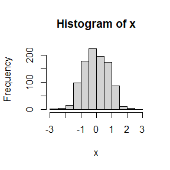

```r
n=1000
lambda=matrix(c(0,1,-1,1/10,-1/2,1/10,0,1/10,1/2,1/10,1,1/10),nrow=6,ncol=2,byrow=TRUE)
P=c(.5,.1,.1,.1,.1,.1)
y=numeric(n)
y=sample(1:6,size=n,replace = TRUE,prob=P)
rate=as.matrix(lambda[y,])
mean1=rate[,1]
sd1=rate[,2]
x=numeric(n)
for (i in 1:n) {
 x[i]=rnorm(1,mean=mean1[i],sd=sd1[i])
}
hist(x)
```

[figure not shown]

```r
hist(x,breaks = "Scott")
```

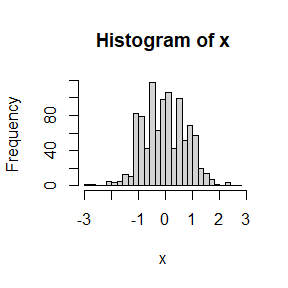

```r
hist(x,breaks = "FD")
```

*2.exercise*

我们需要证明以下： $\bullet$ Suppose that $f^{\prime \prime}$ exists and $h=c n^{-1 / 5}$. Then
$$n^{2 / 5}\left(\hat{f}_{h}-f(x)\right) \leadsto N(\underbrace{\frac{c^{2}}{2} f^{\prime \prime}(x) \kappa_{21}}_{b_{x}}, \underbrace{\frac{1}{c} f(x) \kappa_{02}}_{v_{x}^{2}})$$
因为
$$\hat{f}_{h}(x)-f(x)=\frac{1}{nh}\sum_{i=1}^{n}K\left(\frac{X_{i}-x}{h}\right)-f(x)$$
当$lim_{n\rightarrow0}h=0$，
$$f(x+u h)=f(x)+f^{\prime}(x) u h+\frac{1}{2} f^{\prime \prime}(x)(u h)^{2}+o\left((u h)^{2}\right)$$
因此：

$$\begin{align*}
E \hat{f}_{h}(x) &=E\left[\frac{1}{n} \sum_{i=1}^{n} \frac{1}{h} K\left(\frac{X_{i}-x}{h}\right)\right]=\frac{1}{h} E K\left(\frac{X_{1}-x}{h}\right) \\
&=\int K(u) f(x+u h) d u \\
&=\int K(u)\left[f(x)+f^{\prime}(x) u h+\frac{1}{2} f^{\prime \prime}(x) u^{2} h^{2}+u^{2} o\left(h^{2}\right)\right] d u \\
&=f(x)+\frac{1}{2} f^{\prime \prime}(x) \kappa_{21} h^{2}+o\left(h^{2}\right)
\end{align*}$$

且
$$\begin{array}{l}
\qquad \operatorname{Var}\left(\hat{f}_{h}(x)\right)=\operatorname{Var}\left[\frac{1}{n} \sum_{i=1}^{n} \frac{1}{h} K\left(\frac{X_{i}-x}{h}\right)\right]=\frac{1}{n} \operatorname{Var}\left(\frac{1}{h} K\left(\frac{X_{1}-x}{h}\right)\right) \\
\quad=\frac{1}{n} E\left[\frac{1}{h} K\left(\frac{X_{1}-x}{h}\right)\right]^{2}-\frac{1}{n}\left[E \frac{1}{h} K\left(\frac{X_{1}-x}{h}\right)\right]^{2} \\
\quad=\frac{1}{n h} \int K^{2}(u) f(x+u h) d u-\frac{1}{n}\left(\int K(u) f(x+u h) d u\right)^{2} \\
\quad=\frac{1}{n h} \int K^{2}(u) f(x+u h) d u-\frac{1}{n}\left(f(x)+\frac{1}{2} f^{\prime \prime}(x) \kappa_{21} h^{2}+o\left(h^{2}\right)\right)^{2} \\
\quad=\frac{f(x)}{n h} \kappa_{02}+o\left(\frac{1}{n h}\right)
\end{array}$$
所以可以得到：

$$\begin{align*}
n^{\frac{2}{5}}E\left(\hat{f}_{h}(x)-f(x)\right)&=n^{\frac{2}{5}}\frac{1}{2}f^{\prime \prime}(x)\kappa_{21}h^{2}\qquad(h=cn^{-1/5})\\
&=\frac{c^{2}}{2}f^{\prime \prime}(x)\kappa_{21}\\
&=b_{x}
\end{align*}$$

然后我们有：

$$\begin{align*}
\operatorname{Var}\left(n^{\frac{2}{5}}(\hat{f}_{h}-f(x))\right)&=n^{\frac{4}{5}}\frac{f(x)}{n h} \kappa_{02}\qquad(h=cn^{-1/5})\\
&=\frac{1}{c}f(x)\kappa_{02}\\
&=v_{x}^{2}\\
\end{align*}$$

因此结论成立。

*3.exercise*

[figure not shown]

```r
set.seed(1234)
library(kedd)##先产生100个数据点
n<-100
theta<-matrix(c(0,1,1,0.3),nrow=2,ncol = 2,byrow=TRUE)
y<-sample(1:2,size = n,replace = TRUE,prob = c(0.3,0.7))
z<-as.matrix(theta[y,])
mean2<-z[,1]
sd2<-z[,2]
x<-numeric(n)
for(i in 1:100){
  x[i]<-rnorm(1,mean=mean2[i],sd=sd2[i])
}
## 带宽选择
h=numeric(7)
h[1]=h.amise(x,deriv.order = 0)$h
h[2]=h.mlcv(x,kernel= "gaussian" )$h
h[3]=h.ucv(x,deriv.order = 0)$h
h[4]=h.bcv(x,whichbcv = 1,deriv.order = 0)$h
h[5]=h.ccv(x,deriv.order = 0,upper=0.5)$h
h[6]=h.mcv(x,deriv.order = 0,upper=0.5)$h
h[7]=h.tcv(x,deriv.order = 0)$h
fx=function(x)0.3*dnorm(x,0,1)+0.7*dnorm(x,1,0.3)
hatf=dkde(x,deriv.order = 0,h=h[1])
hatf1=dkde(x,deriv.order = 0,h=h[2])
hatf2=dkde(x,deriv.order = 0,h=h[3])
hatf3=dkde(x,deriv.order = 0,h=h[4])
hatf4=dkde(x,deriv.order = 0,h=h[5])
hatf5=dkde(x,deriv.order = 0,h=h[6])
hatf6=dkde(x,deriv.order = 0,h=h[7])
##画图
z=seq(-3,3,0.05)
plot(z,fx(z),xlab="",ylab="density function",col="black",main = "kernel density estimation",ylim = c(0,1.2),type = "c")
lines(hatf,col="black",lty=2)
lines(hatf1,col="blue")
lines(hatf2,col="black")
lines(hatf3,col="brown")
lines(hatf4,col="blue4")
lines(hatf5,col="antiquewhite4")
lines(hatf6,col="aquamarine4")
par(new=TRUE)
plot(fx,xlab="",xlim=c(-3,3),ylim=c(0,1.2),col="red",lty=2)
legend("topright",legend=c("f(x)","h.amise","h.mlcv","h.ucv","h.bcv","h.ccv","h.mcv","h.tcv"),col=c("red","black","blue","black","brown","blue4","antiquewhite4","aquamarine4"),inset = 0.02,lty=c(2,2,1,1,1,1,1,1))
```

*4.exercise*

需要我们证明:
$$h_{B}=h_{A}\frac{\delta_{0}^{B}}{\delta_{0}^{A}}$$
首先 让$T(K_{A})=\kappa_{02} / \delta_{0}^{A}$, 然后

$$\begin{align*}
A M I S E(K^{A})&=\frac{\left\|K^{A}\right\|^{2}}{n h_{A}}+\frac{h_{A}^{4}}{n}\left\|f^{\prime \prime}\right\|^{2}\mu_{2}^{2}(K^{A})\\
&=\frac{T(K^{A})\delta_{0}^{A}}{n h_{A}}+\frac{h_{A}^{4}}{n(\delta_{0}^{A})^{4}}\left\|f^{\prime \prime}\right\|^{2}T(K^{A})\\
&=\left(\frac{\delta_{0}^{A}}{nh_{A}}+\frac{h_{A}^{4}}{n(\delta_{0}^{A})^{4}}\left\|f^{\prime \prime}\right\|^{2}\right)T(K^{A})\\
\end{align*}$$

让$T(K_{B})=\kappa_{02} / \delta_{0}^{B}$, 然后

$$\begin{align*}
A M I S E(K^{B})&=\frac{\left\|K^{B}\right\|^{2}}{n h_{B}}+\frac{h_{B}^{4}}{n}\left\|f^{\prime \prime}\right\|^{2}\mu_{2}^{2}(K^{B})\\
&=\frac{T(K^{B})\delta_{0}^{B}}{n h_{B}}+\frac{h_{B}^{4}}{n(\delta_{0}^{B})^{4}}\left\|f^{\prime \prime}\right\|^{2}T(K^{B})\\
&=\left(\frac{\delta_{0}^{B}}{nh_{B}}+\frac{h_{B}^{4}}{n(\delta_{0}^{B})^{4}}\left\|f^{\prime \prime}\right\|^{2}\right)T(K^{B})\\
\end{align*}$$

可知要使两者的平滑效果相同，则
$$\begin{array}{l}
\quad AMISE(K^{A})=AMISE(K^{B})\\
\quad \frac{h_{B}}{\delta_{0}^{B}}=\frac{h_{A}}{\delta_{o}^{A}}\\
\quad h_{B}=h_{A}\frac{\delta_{0}^{B}}{\delta_{0}^{A}}\\
\end{array}$$

## 2020-11-24

*1.exercise*

```r
set.seed(12345)
N=1e4
n1=444
n2=132
n3=361
n4=63
n=c(n1,n2,n3,n4)
L=c(0.5,0.3,0.2)
tol= .Machine$double.eps^0.5
L.old=L+1
for (j in 1:N) {
  mu1=1/(2*sum(n))*(n4+n1*(1+(L[1])/(2-2*L[2]-L[1])))
  mu2=1/(2*sum(n))*(n4+n2*(1+(L[2])/(2-2*L[1]-L[2])))
  mu3=1-mu1-mu2
  L=c(mu1,mu2,mu3)
  if (sum(abs(L - L.old)/L.old) < tol) break
  L.old=L
}
print(list(p= L[1],q=L[2], iter = j, tol = tol))
```

2.Record the values of p and q that maximize the conditional likelihood in each EM steps, calculate the corresponding log-maximum likelihood values (for observed data), are they increasing?

```r
set.seed(12345)
N=1e4
n1=444
n2=132
n3=361
n4=63
n=c(n1,n2,n3,n4)
L=c(0.5,0.3,0.2)
tol= .Machine$double.eps^0.5
L.old=L+1
p=numeric(0)
q=numeric(0)
l=numeric(0)
for (j in 1:N) {
  mu1=1/(2*sum(n))*(n4+n1*(1+(L[1])/(2-2*L[2]-L[1])))
  mu2=1/(2*sum(n))*(n4+n2*(1+(L[2])/(2-2*L[1]-L[2])))
  mu3=1-mu1-mu2
  L=c(mu1,mu2,mu3)
  p[j]=mu1
  q[j]=mu2
  l[j]=n1*log(mu1^2+2*mu1*mu3)+n2*log(mu2^2+2*mu2*mu3)+(2*n3)*log(mu3)+n4*log(2*mu1*mu2)
  if (sum(abs(L - L.old)/L.old) < tol) break
  L.old=L
}
print(list(p=p,q=q,l=l))
```

[output not shown]

*2.exercise*

1. 使用lapply函数：

```r
mpg=mtcars$mpg
disp=mtcars$disp
wt=mtcars$wt
formulas=list(
mpg ~ disp,
mpg ~ I(1 / disp),
mpg ~ disp + wt,
mpg ~ I(1 / disp) + wt
)
fit.models=function(i){
  lm(formulas[[i]])
}
lapply(seq_along(formulas), fit.models)
```

```
## [[1]]
##
## Call:
## lm(formula = formulas[[i]])
##
## Coefficients:
## (Intercept)         disp
##    29.59985     -0.04122
##
##
## [[2]]
##
## Call:
## lm(formula = formulas[[i]])
##
## Coefficients:
## (Intercept)    I(1/disp)
##       10.75      1557.67
##
##
## [[3]]
##
## Call:
## lm(formula = formulas[[i]])
##
## Coefficients:
## (Intercept)         disp           wt
##    34.96055     -0.01772     -3.35083
##
##
## [[4]]
##
## Call:
## lm(formula = formulas[[i]])
##
## Coefficients:
## (Intercept)    I(1/disp)           wt
##      19.024     1142.560       -1.798
```

2.使用loop循环：

```r
mpg=mtcars$mpg
disp=mtcars$disp
wt=mtcars$wt
formulas=list(
mpg ~ disp,
mpg ~ I(1 / disp),
mpg ~ disp + wt,
mpg ~ I(1 / disp) + wt
)
out=vector("list", length(formulas))
for (i in seq_along(formulas)) {
out[[i]]=lm(formulas[[i]])
}
out
```

```
## [[1]]
##
## Call:
## lm(formula = formulas[[i]])
##
## Coefficients:
## (Intercept)         disp
##    29.59985     -0.04122
##
##
## [[2]]
##
## Call:
## lm(formula = formulas[[i]])
##
## Coefficients:
## (Intercept)    I(1/disp)
##       10.75      1557.67
##
##
## [[3]]
##
## Call:
## lm(formula = formulas[[i]])
##
## Coefficients:
## (Intercept)         disp           wt
##    34.96055     -0.01772     -3.35083
##
##
## [[4]]
##
## Call:
## lm(formula = formulas[[i]])
##
## Coefficients:
## (Intercept)    I(1/disp)           wt
##      19.024     1142.560       -1.798
```

*3.exercise*

```r
set.seed(1234)
##the anonymous function is defined
trials <- replicate(
100,
t.test(rpois(10, 10), rpois(7, 10)),
simplify = FALSE
)
sapply(trials,function(f)f$p.value)
```

```
##   [1] 0.92573839 0.38341791 0.21070462 0.41458918 0.26121206 0.72223937
##   [7] 0.29887169 0.95162894 0.26398664 0.62018151 0.51388383 0.94676108
##  [13] 0.05206634 0.94395869 0.90872276 0.91948631 0.66419598 0.29837025
##  [19] 0.29940554 0.83506207 0.45274078 0.90320828 0.79263778 0.45399170
##  [25] 0.38923722 0.69542630 0.26739653 0.38567329 0.31137487 0.36010634
##  [31] 0.39754771 0.72253407 0.42186171 0.12771643 0.23170443 0.68265125
##  [37] 0.71252902 0.12724649 0.75353630 0.94884686 0.87276882 0.41388298
##  [43] 0.25224053 0.84404036 0.16580146 0.42473329 0.82280924 0.71272703
##  [49] 0.30947058 0.92816784 0.27134690 0.62008647 0.49758173 0.02775463
##  [55] 0.78775614 0.26248714 0.77273771 0.68416168 0.08687832 0.04574362
##  [61] 0.44178950 0.36827740 0.64265435 0.47847663 0.10832740 0.75695184
##  [67] 0.61642417 0.01474650 0.18023871 0.42316145 0.38702375 0.27030894
##  [73] 0.92266032 0.75504614 0.65781938 0.34910615 0.22083614 0.53165720
##  [79] 0.14727409 0.50490437 0.42920650 0.71256710 0.72931439 0.90676814
##  [85] 0.85988192 0.87366680 0.91047506 0.99255659 0.15198012 0.09537499
##  [91] 0.37213020 0.96151424 0.97595090 0.30669922 0.42738809 0.75571001
##  [97] 0.15155800 0.06214524 0.29324608 0.83599679
```

```r
x=list(runif(11), runif(6))
y=list(rpois(11, 2) + 1, rpois(6, 2) + 1)
vapply(Map(weighted.mean,x,y),function(x) x,FUN.VALUE = c(a=0))
```

```
## [1] 0.4950823 0.3812716
```

## 2020-12-01

*2.exercise*

That is the R function we wrote before.

```r
set.seed(3000)
lap_f = function(x) exp(-abs(x))
rw.Metropolis = function(sigma, x0, N){
 x = numeric(N)
 x[1] = x0
 u = runif(N)
 k = 0
 for (i in 2:N) {
  y = rnorm(1, x[i-1], sigma)
  if (u[i] <= (lap_f(y) / lap_f(x[i-1]))) x[i] = y
  else {
  x[i] = x[i-1]
  k = k+1
  }
 }
 return(list(x = x, k = k))
}
N = 2000
sigma = c(.05, .5, 2, 16)
x0 = 25
rw1 = rw.Metropolis(sigma[1],x0,N)
rw2 = rw.Metropolis(sigma[2],x0,N)
rw3 = rw.Metropolis(sigma[3],x0,N)
rw4 = rw.Metropolis(sigma[4],x0,N)
#number of candidate points rejected
Rej = cbind(rw1$k, rw2$k, rw3$k, rw4$k)
Acc = round((N-Rej)/N,4)
rownames(Acc) = "Accept rates"
colnames(Acc) = paste("sigma",sigma)
knitr::kable(Acc)
#plot
par(mfrow=c(2,2))  #display 4 graphs together
    rw = cbind(rw1$x, rw2$x, rw3$x,  rw4$x)
    for (j in 1:4) {
        plot(rw[,j], type="l",
             xlab=bquote(sigma == .(round(sigma[j],3))),
             ylab="X", ylim=range(rw[,j]))
    }
```

[output not shown]

```r
o=ppoints(100)
zr=numeric(100)
for (i in 1:100) {
  zr[i]=log(2*(o[i]))*as.numeric(o[i]<=0.5)+(-log(2-2*o[i]))*as.numeric(o[i]>0.5)
}
zx1=quantile(y1,o)
zx2=quantile(y2,o)
zx3=quantile(y3,o)
zx4=quantile(y4,o)
zy1=quantile(rw1$x,o)
zy2=quantile(rw2$x,o)
zy3=quantile(rw3$x,o)
zy4=quantile(rw4$x,o)
qqplot(zx1,zy1,xlab = "RcPP Function",ylab ="R Function" )
qqline(zy1)
par(mfrow=c(1,1))
qqplot(zx2,zy2,xlab = "RcPP Function",ylab ="R Function")
qqline(zy2)
par(mfrow=c(1,1))
qqplot(zx3,zy3,xlab = "RcPP Function",ylab ="R Function")
qqline(zy3)
par(mfrow=c(1,1))
qqplot(zx4,zy4,xlab = "RcPP Function",ylab ="R Function")
qqline(zy4)
```